# Hyne Tumbarumba Trial: Green Board Data

Jonathan Harrington

# Todo

- grab a lot more example data for comparison. i.e. typical green board density/stiffness distributions
- more green ecoustic data from Tumbarumba
- more green density/swv data from other sources. DONE (see HPPViSCAN comparison below)
- why is MOE=6.50 over-represented? DONE, 6.5 used as default value
- check that ecoustic MOE is based on $\rho v^2$ rather than some empirical correlation. DONE, apparently yes
- classify boards as cant or side. DONE

# Background

### Trimmer

Green board shape could not be collected. USNR software crashed whenever writing shape data to disk enabled.

Data collected USNR database on TRIMMER2.

### SICK Camera

Power was lost briefly around 11:40a (someone tripped over the power cord?).

(see `sick.Rmd`)

### Ecoustic

Ecoustic data collected as csv file copied from Ecoustic2 PC by ML.

Loaded into HYNE database using `ecoustic-create.sql` and `ecoustic2db.py`.

# Ecoustic Dataset

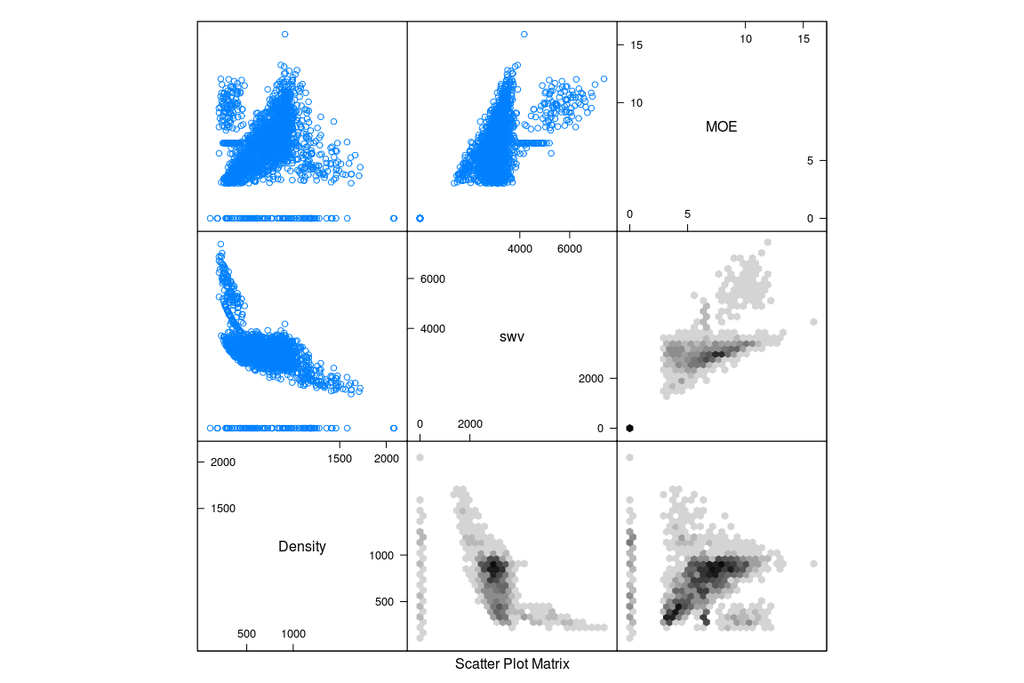

```r
ch = odbcConnect('HYNE','sa','password12')
E = sqlQuery(ch, "select Timestamp, ScheduledDimensions, Width, Thickness, Length, Weight, Density, MOE from ecoustic")
E$swv = sqrt(E$MOE/E$Density*1e9)
E$f1 = E$swv/2/E$Length
#pairs(E[,3:10])
#pairs(E[,c(7,9,8)])
splom(E[,c('Density','swv','MOE')], lower.panel=function(x,y,...){panel.hexbinplot(x,y)})
```

What causes the cloud of low density high SWV results? Incorrect frequency measured? Different relationship used to determine MOE (remember here SWV is back calculated from MOE and density assuming $v^2=E/\rho$)

## Board properties through time

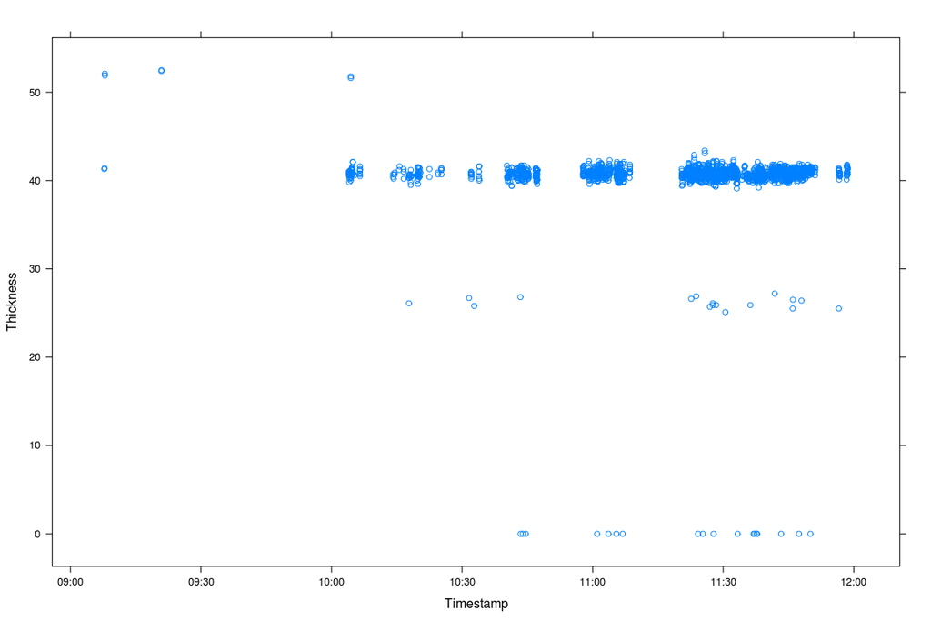

```r
xyplot(Thickness ~ Timestamp, E)
```

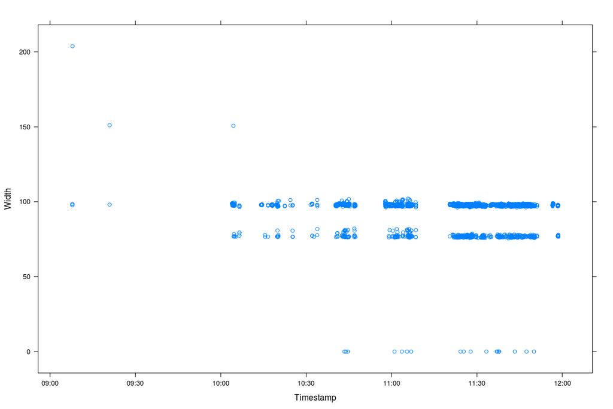

```r
xyplot(Width ~ Timestamp, E)
```

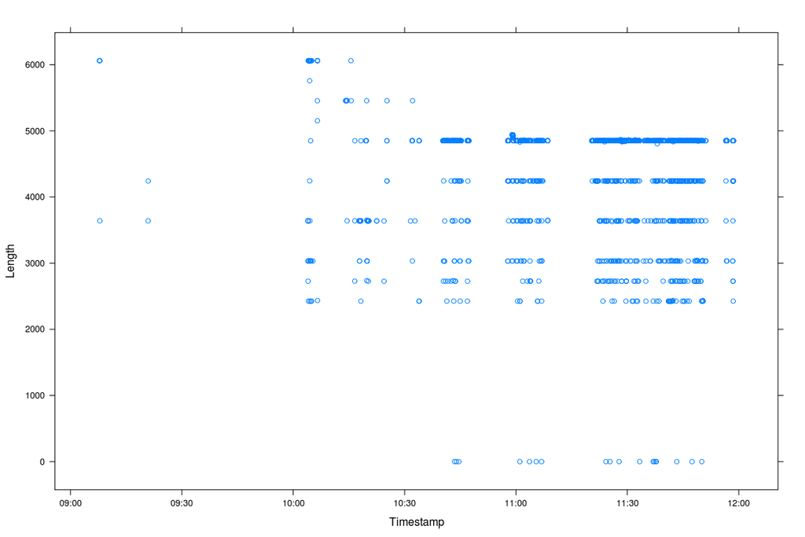

```r
xyplot(Length ~ Timestamp, E)
```

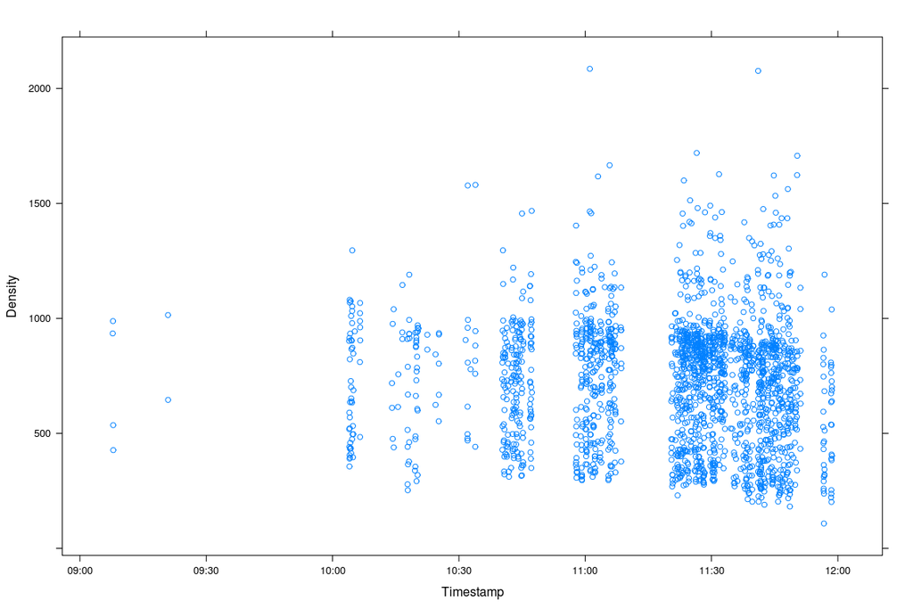

```r
xyplot(Density ~ Timestamp, E)
```

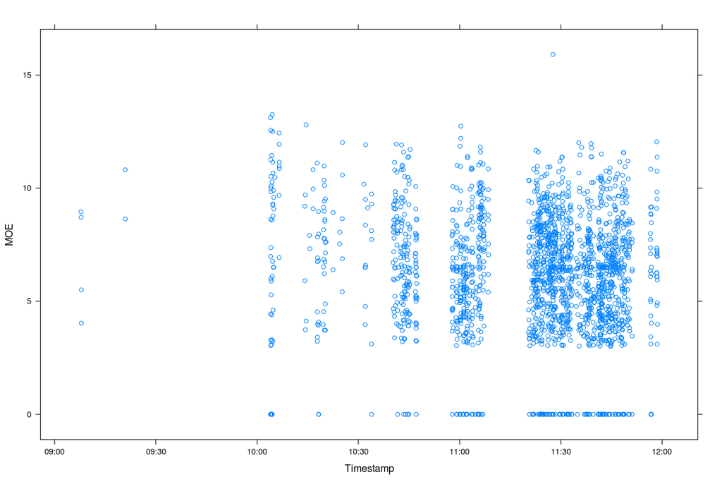

```r
xyplot(MOE ~ Timestamp, E)
```

```r
#summary(lm(MOE ~ ScaledMOE, E)) # MOE = ScaledMOE
```

What does Length=Thickness=Width=0 denote? All have Grade=‘Not graded’.

Where does the board dimension data come from? The Trimmer2 scanner? Yes, via PLC (not db).

```r
sum(E$Length==0) # 18 length=width=thickness=0
```

```
## [1] 18
```

```r
sum(E$Density<=0) # 0
```

```
## [1] NA
```

```r
sum(E$Weight<=0) # 0
```

```
## [1] 0
```

```r
sum(E$MOE==0) # 122
```

```
## [1] 122
```

```r
E$MOE[E$Length==0] # always 0
```

```
##  [1] 0 0 0 0 0 0 0 0 0 0 0 0 0 0 0 0 0 0
```

```r
E$MOE[E$Width==0] # always 0
```

```
##  [1] 0 0 0 0 0 0 0 0 0 0 0 0 0 0 0 0 0 0
```

```r
E[E$MOE==6.50,] # nothing unusual
```

```
##                Timestamp ScheduledDimensions Width Thickness Length Weight
## 45   2014-08-31 10:04:50         100x38x7000  98.1      41.3   2425   5.23
## 47   2014-08-31 10:04:56          75x38x7000  76.8      42.1   2425   3.89
## 119  2014-08-31 10:32:03         100x38x7000  98.7      40.8   4850   9.34
## 120  2014-08-31 10:32:04         100x38x7000  98.6      41.0   4850   9.19
## 152  2014-08-31 10:40:48         100x38x7000  97.8      40.7   3637   4.66
## 181  2014-08-31 10:41:54         100x38x7000  98.5      40.7   4850   6.05
## 265  2014-08-31 10:44:50         100x38x7000  98.5      40.7   4850   6.12
## 305  2014-08-31 10:47:09         100x38x7000  98.3      41.2   4850  10.34
## 307  2014-08-31 10:47:11         100x38x7000  97.6      40.7   4850   8.86
## 320  2014-08-31 10:57:46         100x38x7000  97.1      40.7   4243  17.19
## 325  2014-08-31 10:57:50         100x38x7000  98.1      41.4   4850  11.86
## 365  2014-08-31 10:59:15         100x38x7000  98.7      40.7   4921   6.32
## 390  2014-08-31 11:00:13         100x38x7000  97.7      41.0   4850   8.32
## 405  2014-08-31 11:00:23         100x38x7000  98.3      40.7   4850   8.12
```

[output cut: 113 more lines]

### Board property distributions

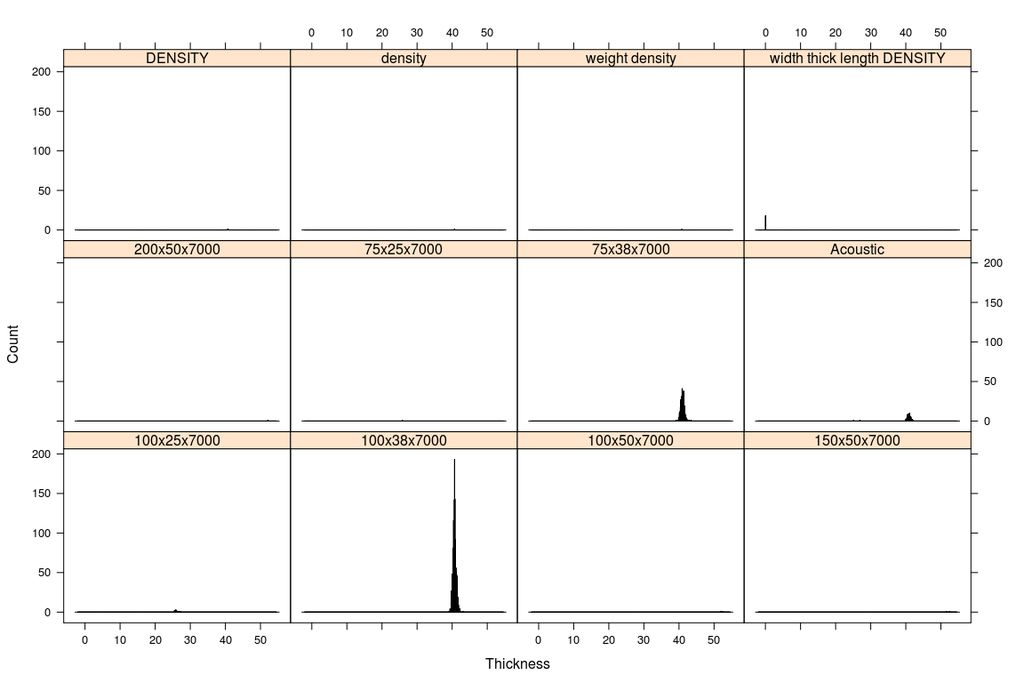

```r
histogram(~Thickness | ScheduledDimensions, E, nint=1000, type='count')
```

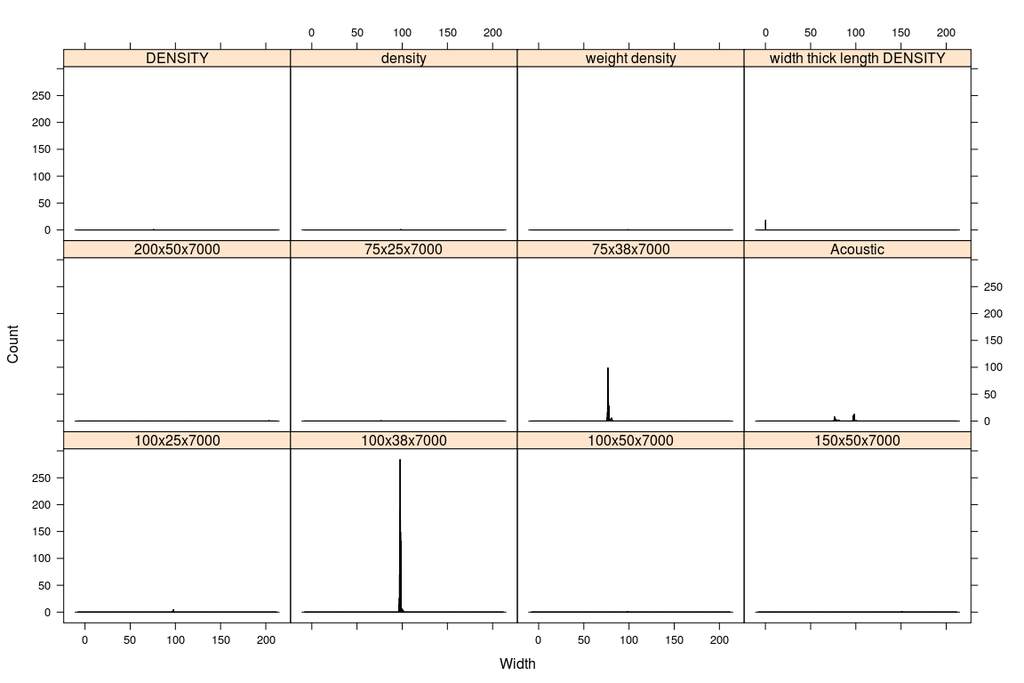

```r
histogram(~Width | ScheduledDimensions, E, nint=1000, type='count')
```

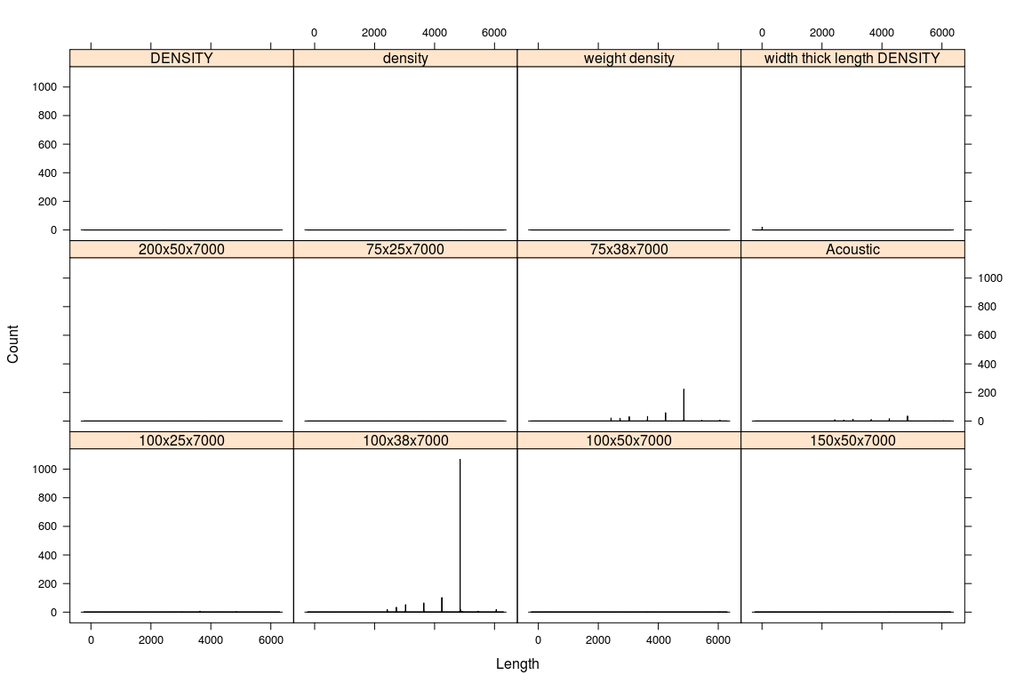

```r
histogram(~Length | ScheduledDimensions, E, nint=1000, type='count')
```

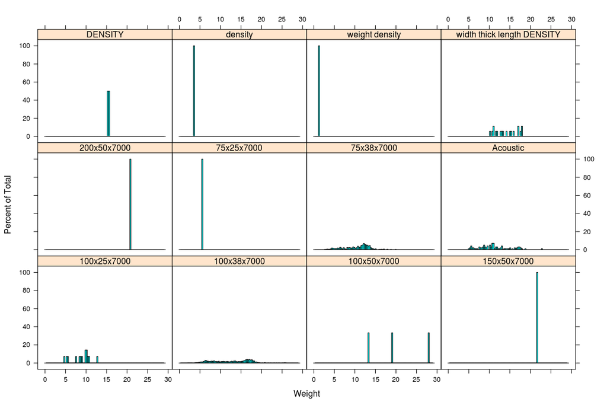

```r
histogram(~Weight | ScheduledDimensions, E, nint=100)
```

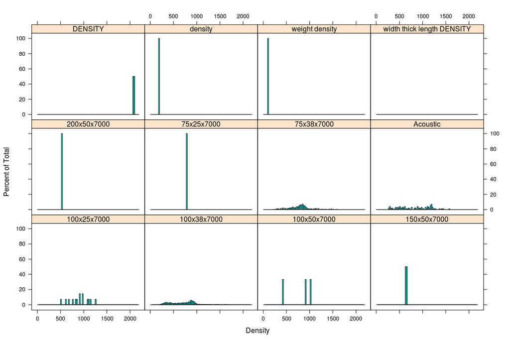

```r
histogram(~Density | ScheduledDimensions, E, nint=100)
```

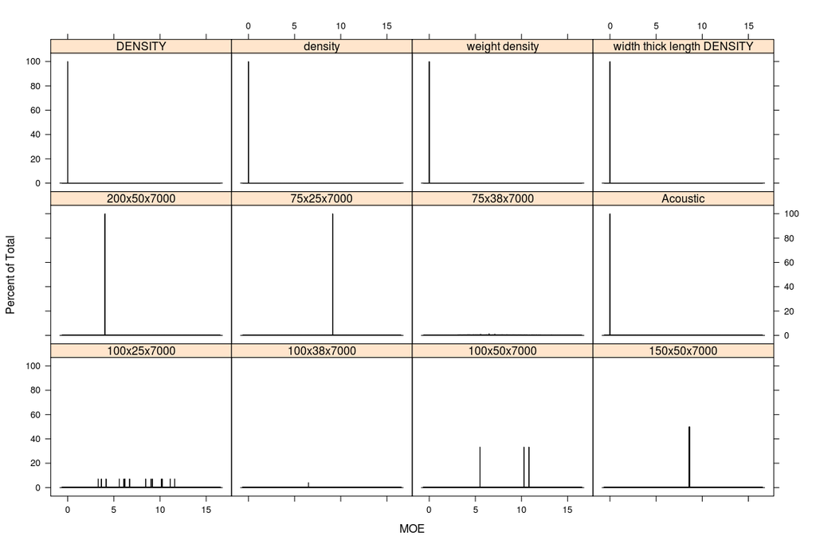

```r
histogram(~MOE | ScheduledDimensions, E, nint=10001)
```

~6% of boards have densities>1100 kg/m^3, these are considered unreasonable (a fully saturated board of basic density 500 kg/m^3 has a green density of 1166 kg/m^3).

Why does MOE=6.50 occur way more often than it should?

> On the question below there are some cases where 6.5 MoE is assumed. It happens when the confidence in the velocity is low (~50%) but the mill wanted a conservative approach (don’t throw potentially good boards out) so 6.5 is assigned. The real MoE could be above or below that. One reason the confidence could be low on trimmer line 2 is that there can be some bouncing of the test boards away from the hammer when the next large board hits the fence after the trimmer. There is no record in the file of which boards had low confidence.

## HPP ViSCAN comparison

TODO: compare current data with ViSCAN data from HPP

Green resonance of 1156 ~6m radiata pine boards measured using Microtec ViSCAN tool. Density from ? Matched to dry bending stiffness.

```r
H = sqlQuery(ch, "select 'viscan' as dataset, greenSWV as swv, greenDEN as Density, dryMOEavg, dryMOElow from HPPviscan")
E$dataset = "ecoustic"
EH = rbind(H[,c("dataset","swv","Density")],E[,c("dataset","swv","Density")])
str(EH)
```

```
## 'data.frame':    3166 obs. of  3 variables:
##  $ dataset: Factor w/ 2 levels "viscan","ecoustic": 1 1 1 1 1 1 1 1 1 1 ...
##  $ swv    : num  4200 4860 3840 4428 4032 ...
##  $ Density: num  597 639 568 582 610 661 584 583 660 660 ...
```

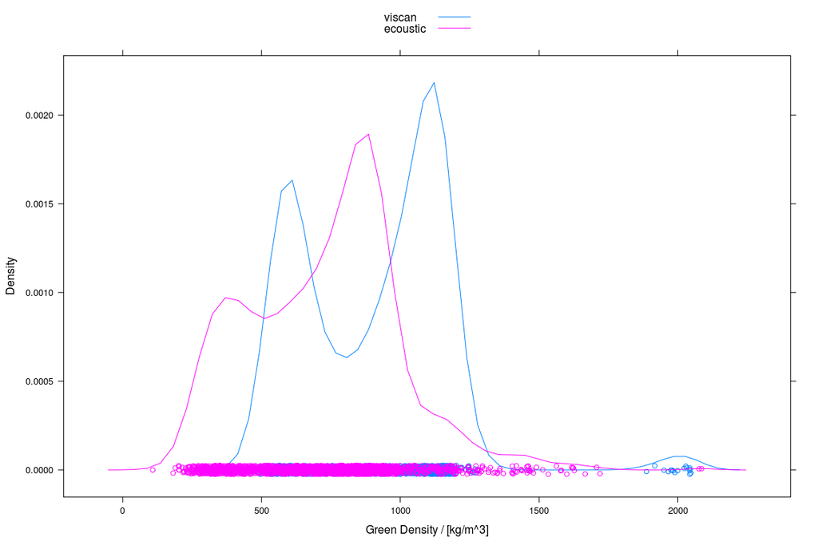

```r
densityplot(~Density, group=dataset, EH, auto.key=TRUE, xlab="Green Density / [kg/m^3]")
```

```r
ddply(EH, .(dataset), summarize, med=median(Density, na.rm=TRUE))
```

```
##    dataset    med
## 1   viscan 964.00
## 2 ecoustic 763.88
```

Both distributions show bimodal density (heartwood, sapwood), but the ecoustic density is substantially lower.

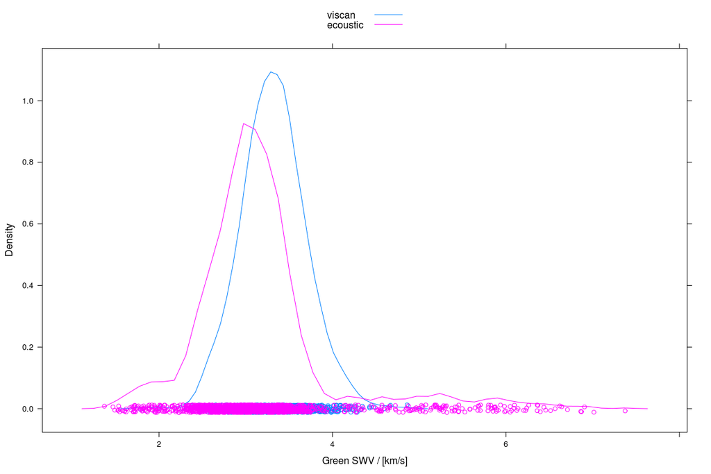

```r
densityplot(~swv/1000, group=dataset, EH, auto.key=TRUE, xlab="Green SWV / [km/s]", subset=swv>0)
```

```r
ddply(EH, .(dataset), summarize, med=median(swv, na.rm=TRUE))
```

```
##    dataset      med
## 1   viscan 3312.000
## 2 ecoustic 3032.886
```

Ecoustic distribution noisier and with a slightly lower mode.

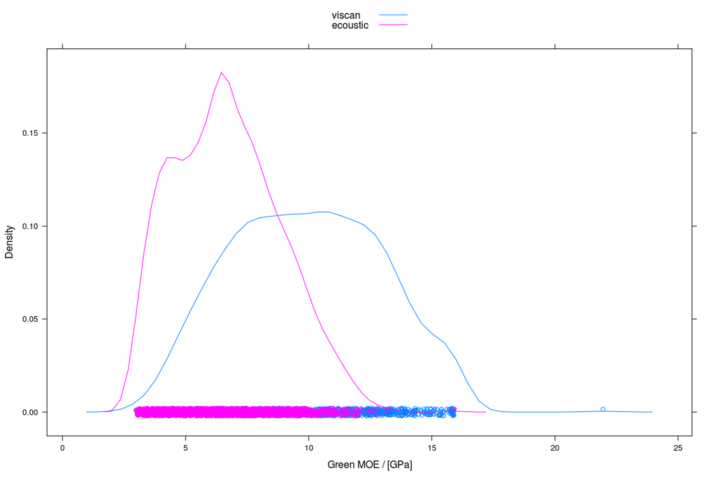

```r
EH$moe=EH$swv^2*EH$Density/1e9
densityplot(~moe, group=dataset, EH, auto.key=TRUE, xlab="Green MOE / [GPa]", subset=swv>0)
```

```r
ddply(EH, .(dataset), summarize, med=median(moe, na.rm=TRUE))
```

```
##    dataset      med
## 1   viscan 9.905753
## 2 ecoustic 6.495000
```

Hmmm. Quite different.

Finally, take a look at the green-dry comparison:

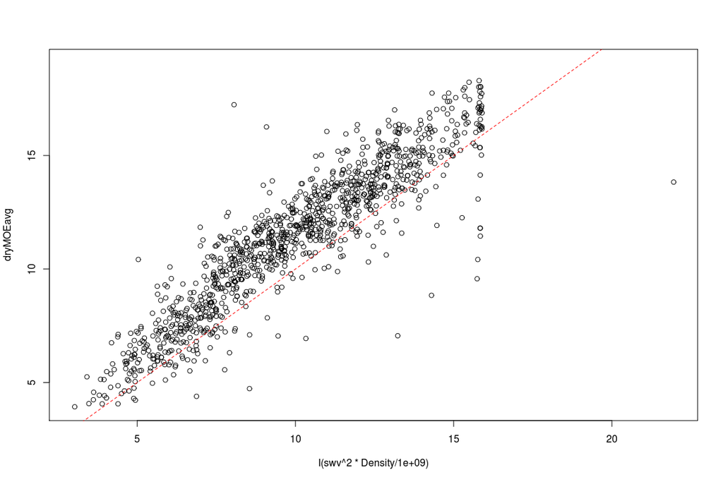

```r
plot(dryMOEavg ~ I(swv^2*Density/1e9), H)
abline(c(0,1), col="red", lty=2)
```

Remember that a 1st order estimate is:

$\frac{v_g^2}{v_d^2} = \frac{\rho_d}{\rho_g}$